# Risk Factor Analysis

## Outcome Variable

**Outcome Variable:** swasted

## Predictor Variables

**Intervention Variable:** feducyrs

**Adjustment Set:**

- arm
- W_mage
- meducyrs
- hhwealth_quart
- W_mhtcm
- W_gagebrth
- W_birthwt
- W_birthlen
- W_nrooms
- impfloor
- impsan
- safeh20
- delta_W_mage
- delta_meducyrs
- delta_hhwealth_quart
- delta_W_mhtcm
- delta_W_gagebrth
- delta_W_birthwt
- delta_W_birthlen
- delta_W_nrooms
- delta_impfloor
- delta_impsan
- delta_safeh20

## Stratifying Variables

The analysis was stratified on these variable(s):

- agecat
- studyid
- country

## Data Summary

| agecat | studyid | country | feducyrs | swasted | n_cell | n |
| --- | --- | --- | --- | --- | --- | --- |
| Birth | ki0047075b-MAL-ED | BANGLADESH | Low | 0 | 32 | 134 |
| Birth | ki0047075b-MAL-ED | BANGLADESH | Low | 1 | 3 | 134 |
| Birth | ki0047075b-MAL-ED | BANGLADESH | Medium | 0 | 49 | 134 |
| Birth | ki0047075b-MAL-ED | BANGLADESH | Medium | 1 | 1 | 134 |
| Birth | ki0047075b-MAL-ED | BANGLADESH | High | 0 | 47 | 134 |
| Birth | ki0047075b-MAL-ED | BANGLADESH | High | 1 | 2 | 134 |
| Birth | ki0047075b-MAL-ED | INDIA | Low | 0 | 46 | 121 |
| Birth | ki0047075b-MAL-ED | INDIA | Low | 1 | 2 | 121 |
| Birth | ki0047075b-MAL-ED | INDIA | Medium | 0 | 35 | 121 |
| Birth | ki0047075b-MAL-ED | INDIA | Medium | 1 | 0 | 121 |
| Birth | ki0047075b-MAL-ED | INDIA | High | 0 | 38 | 121 |
| Birth | ki0047075b-MAL-ED | INDIA | High | 1 | 0 | 121 |
| Birth | ki0047075b-MAL-ED | NEPAL | Low | 0 | 18 | 64 |
| Birth | ki0047075b-MAL-ED | NEPAL | Low | 1 | 0 | 64 |
| Birth | ki0047075b-MAL-ED | NEPAL | Medium | 0 | 19 | 64 |
| Birth | ki0047075b-MAL-ED | NEPAL | Medium | 1 | 0 | 64 |
| Birth | ki0047075b-MAL-ED | NEPAL | High | 0 | 27 | 64 |
| Birth | ki0047075b-MAL-ED | NEPAL | High | 1 | 0 | 64 |
| Birth | ki0047075b-MAL-ED | PERU | Low | 0 | 63 | 230 |
| Birth | ki0047075b-MAL-ED | PERU | Low | 1 | 0 | 230 |
| Birth | ki0047075b-MAL-ED | PERU | Medium | 0 | 55 | 230 |
| Birth | ki0047075b-MAL-ED | PERU | Medium | 1 | 0 | 230 |
| Birth | ki0047075b-MAL-ED | PERU | High | 0 | 112 | 230 |
| Birth | ki0047075b-MAL-ED | PERU | High | 1 | 0 | 230 |
| Birth | ki0047075b-MAL-ED | SOUTH AFRICA | Low | 0 | 30 | 91 |
| Birth | ki0047075b-MAL-ED | SOUTH AFRICA | Low | 1 | 0 | 91 |
| Birth | ki0047075b-MAL-ED | SOUTH AFRICA | Medium | 0 | 26 | 91 |
| Birth | ki0047075b-MAL-ED | SOUTH AFRICA | Medium | 1 | 0 | 91 |
| Birth | ki0047075b-MAL-ED | SOUTH AFRICA | High | 0 | 35 | 91 |
| Birth | ki0047075b-MAL-ED | SOUTH AFRICA | High | 1 | 0 | 91 |

[output cut: 288 more lines]

The following strata were considered:

- agecat: 24 months, studyid: ki0047075b-MAL-ED, country: BANGLADESH
- agecat: 24 months, studyid: ki0047075b-MAL-ED, country: INDIA
- agecat: 24 months, studyid: ki0047075b-MAL-ED, country: NEPAL
- agecat: 24 months, studyid: ki0047075b-MAL-ED, country: PERU
- agecat: 24 months, studyid: ki0047075b-MAL-ED, country: SOUTH AFRICA
- agecat: 24 months, studyid: ki0047075b-MAL-ED, country: TANZANIA, UNITED REPUBLIC OF
- agecat: 24 months, studyid: ki1017093b-PROVIDE, country: BANGLADESH
- agecat: 24 months, studyid: ki1017093c-NIH-Crypto, country: BANGLADESH
- agecat: 24 months, studyid: ki1066203-TanzaniaChild2, country: TANZANIA, UNITED REPUBLIC OF
- agecat: 24 months, studyid: ki1113344-GMS-Nepal, country: NEPAL
- agecat: 24 months, studyid: ki1119695-PROBIT, country: BELARUS
- agecat: 24 months, studyid: ki1126311-ZVITAMBO, country: ZIMBABWE
- agecat: 24 months, studyid: ki1135781-COHORTS, country: GUATEMALA
- agecat: 24 months, studyid: ki1135781-COHORTS, country: INDIA
- agecat: 24 months, studyid: ki1135781-COHORTS, country: PHILIPPINES
- agecat: 24 months, studyid: ki1148112-LCNI-5, country: MALAWI
- agecat: 24 months, studyid: kiGH5241-JiVitA-3, country: BANGLADESH
- agecat: 24 months, studyid: kiGH5241-JiVitA-4, country: BANGLADESH
- agecat: 6 months, studyid: ki0047075b-MAL-ED, country: BANGLADESH
- agecat: 6 months, studyid: ki0047075b-MAL-ED, country: INDIA
- agecat: 6 months, studyid: ki0047075b-MAL-ED, country: NEPAL
- agecat: 6 months, studyid: ki0047075b-MAL-ED, country: PERU
- agecat: 6 months, studyid: ki0047075b-MAL-ED, country: SOUTH AFRICA
- agecat: 6 months, studyid: ki0047075b-MAL-ED, country: TANZANIA, UNITED REPUBLIC OF
- agecat: 6 months, studyid: ki1000304b-SAS-CompFeed, country: INDIA
- agecat: 6 months, studyid: ki1000304b-SAS-FoodSuppl, country: INDIA
- agecat: 6 months, studyid: ki1017093b-PROVIDE, country: BANGLADESH
- agecat: 6 months, studyid: ki1017093c-NIH-Crypto, country: BANGLADESH
- agecat: 6 months, studyid: ki1066203-TanzaniaChild2, country: TANZANIA, UNITED REPUBLIC OF
- agecat: 6 months, studyid: ki1113344-GMS-Nepal, country: NEPAL
- agecat: 6 months, studyid: ki1119695-PROBIT, country: BELARUS
- agecat: 6 months, studyid: ki1126311-ZVITAMBO, country: ZIMBABWE
- agecat: 6 months, studyid: ki1135781-COHORTS, country: GUATEMALA
- agecat: 6 months, studyid: ki1135781-COHORTS, country: INDIA
- agecat: 6 months, studyid: ki1135781-COHORTS, country: PHILIPPINES
- agecat: 6 months, studyid: ki1148112-LCNI-5, country: MALAWI
- agecat: 6 months, studyid: kiGH5241-JiVitA-3, country: BANGLADESH
- agecat: 6 months, studyid: kiGH5241-JiVitA-4, country: BANGLADESH
- agecat: Birth, studyid: ki0047075b-MAL-ED, country: BANGLADESH
- agecat: Birth, studyid: ki0047075b-MAL-ED, country: INDIA
- agecat: Birth, studyid: ki0047075b-MAL-ED, country: NEPAL
- agecat: Birth, studyid: ki0047075b-MAL-ED, country: PERU
- agecat: Birth, studyid: ki0047075b-MAL-ED, country: SOUTH AFRICA
- agecat: Birth, studyid: ki0047075b-MAL-ED, country: TANZANIA, UNITED REPUBLIC OF
- agecat: Birth, studyid: ki1000304b-SAS-CompFeed, country: INDIA
- agecat: Birth, studyid: ki1017093c-NIH-Crypto, country: BANGLADESH
- agecat: Birth, studyid: ki1119695-PROBIT, country: BELARUS
- agecat: Birth, studyid: ki1126311-ZVITAMBO, country: ZIMBABWE
- agecat: Birth, studyid: ki1135781-COHORTS, country: GUATEMALA
- agecat: Birth, studyid: ki1135781-COHORTS, country: INDIA
- agecat: Birth, studyid: ki1135781-COHORTS, country: PHILIPPINES
- agecat: Birth, studyid: kiGH5241-JiVitA-3, country: BANGLADESH
- agecat: Birth, studyid: kiGH5241-JiVitA-4, country: BANGLADESH

### Dropped Strata

Some strata were dropped due to rare outcomes:

- agecat: Birth, studyid: ki0047075b-MAL-ED, country: BANGLADESH
- agecat: Birth, studyid: ki0047075b-MAL-ED, country: INDIA
- agecat: Birth, studyid: ki0047075b-MAL-ED, country: NEPAL
- agecat: Birth, studyid: ki0047075b-MAL-ED, country: PERU
- agecat: Birth, studyid: ki0047075b-MAL-ED, country: SOUTH AFRICA
- agecat: Birth, studyid: ki0047075b-MAL-ED, country: TANZANIA, UNITED REPUBLIC OF
- agecat: Birth, studyid: ki1000304b-SAS-CompFeed, country: INDIA
- agecat: Birth, studyid: ki1017093c-NIH-Crypto, country: BANGLADESH
- agecat: Birth, studyid: kiGH5241-JiVitA-4, country: BANGLADESH
- agecat: 6 months, studyid: ki0047075b-MAL-ED, country: BANGLADESH
- agecat: 6 months, studyid: ki0047075b-MAL-ED, country: INDIA
- agecat: 6 months, studyid: ki0047075b-MAL-ED, country: NEPAL
- agecat: 6 months, studyid: ki0047075b-MAL-ED, country: PERU
- agecat: 6 months, studyid: ki0047075b-MAL-ED, country: SOUTH AFRICA
- agecat: 6 months, studyid: ki0047075b-MAL-ED, country: TANZANIA, UNITED REPUBLIC OF
- agecat: 6 months, studyid: ki1017093b-PROVIDE, country: BANGLADESH
- agecat: 6 months, studyid: ki1017093c-NIH-Crypto, country: BANGLADESH
- agecat: 6 months, studyid: ki1066203-TanzaniaChild2, country: TANZANIA, UNITED REPUBLIC OF
- agecat: 6 months, studyid: ki1113344-GMS-Nepal, country: NEPAL
- agecat: 6 months, studyid: ki1119695-PROBIT, country: BELARUS
- agecat: 6 months, studyid: ki1135781-COHORTS, country: GUATEMALA
- agecat: 6 months, studyid: ki1148112-LCNI-5, country: MALAWI
- agecat: 6 months, studyid: kiGH5241-JiVitA-4, country: BANGLADESH
- agecat: 24 months, studyid: ki0047075b-MAL-ED, country: BANGLADESH
- agecat: 24 months, studyid: ki0047075b-MAL-ED, country: INDIA
- agecat: 24 months, studyid: ki0047075b-MAL-ED, country: NEPAL
- agecat: 24 months, studyid: ki0047075b-MAL-ED, country: PERU
- agecat: 24 months, studyid: ki0047075b-MAL-ED, country: SOUTH AFRICA
- agecat: 24 months, studyid: ki0047075b-MAL-ED, country: TANZANIA, UNITED REPUBLIC OF
- agecat: 24 months, studyid: ki1017093b-PROVIDE, country: BANGLADESH
- agecat: 24 months, studyid: ki1017093c-NIH-Crypto, country: BANGLADESH
- agecat: 24 months, studyid: ki1066203-TanzaniaChild2, country: TANZANIA, UNITED REPUBLIC OF
- agecat: 24 months, studyid: ki1119695-PROBIT, country: BELARUS
- agecat: 24 months, studyid: ki1126311-ZVITAMBO, country: ZIMBABWE
- agecat: 24 months, studyid: ki1135781-COHORTS, country: GUATEMALA
- agecat: 24 months, studyid: ki1135781-COHORTS, country: INDIA
- agecat: 24 months, studyid: ki1135781-COHORTS, country: PHILIPPINES
- agecat: 24 months, studyid: ki1148112-LCNI-5, country: MALAWI

## Methods Detail

We’re interested in the causal parameters $E[Y_a]$ for all values of $a \in \mathcal{A}$. These parameters represent the mean outcome if, possibly contrary to fact, we intervened to set all units to have $A=a$. Under the randomization and positivity assumptions, these are identified by the statistical parameters $\psi_a=E_W[E_{Y|A,W}(Y|A=a,W)]$. In addition, we’re interested in the mean of $Y$, $E[Y]$ under no intervention (the observed mean). We will estimate these parameters by using SuperLearner to fit the relevant likelihood factors – $E_{Y|A,W}(Y|A=a,W)$ and $p(A=a|W)$, and then updating our likelihood fit using a joint TMLE.

For unadjusted analyses ($W=\{\}$), initial likelihoods were estimated using Lrnr_glm to estimate the simple $E(Y|A)$ and Lrnr_mean to estimate $p(A)$. For adjusted analyses, a small library containing Lrnr_glmnet, Lrnr_xgboost, and Lrnr_mean was used.

Having estimated these parameters, we will then use the delta method to estimate relative risks and attributable risks relative to a prespecified baseline level of $A$.

# Results Detail

## Results Plots

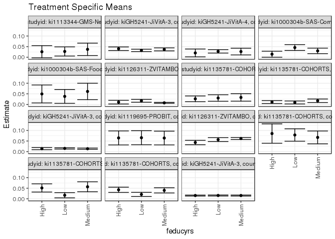

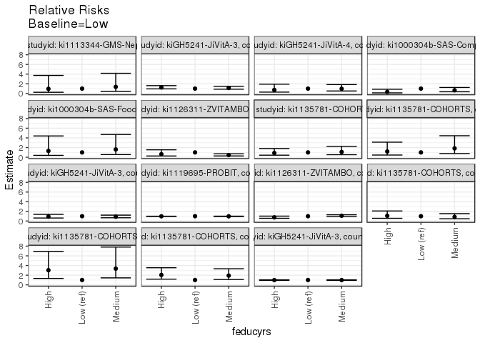

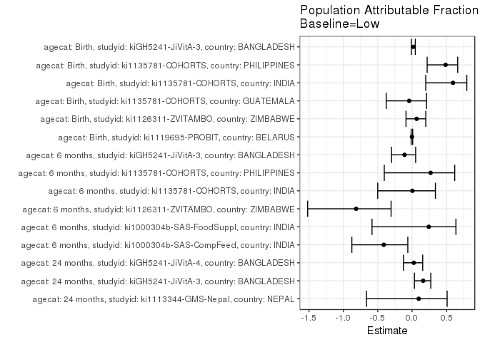

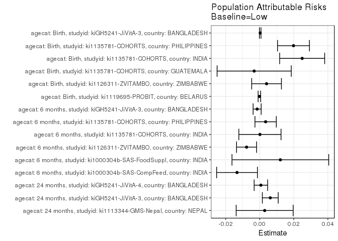

## Results Table

### Parameter: TSM

| agecat | studyid | country | intervention_level | baseline_level | estimate | ci_lower | ci_upper |
| --- | --- | --- | --- | --- | --- | --- | --- |
| Birth | ki1119695-PROBIT | BELARUS | Low | NA | 0.0656038 | 0.0324201 | 0.0987875 |
| Birth | ki1119695-PROBIT | BELARUS | Medium | NA | 0.0641362 | 0.0316537 | 0.0966186 |
| Birth | ki1119695-PROBIT | BELARUS | High | NA | 0.0645879 | 0.0315566 | 0.0976193 |
| Birth | ki1126311-ZVITAMBO | ZIMBABWE | Low | NA | 0.0566742 | 0.0473472 | 0.0660013 |
| Birth | ki1126311-ZVITAMBO | ZIMBABWE | Medium | NA | 0.0617707 | 0.0570771 | 0.0664643 |
| Birth | ki1126311-ZVITAMBO | ZIMBABWE | High | NA | 0.0430751 | 0.0325675 | 0.0535827 |
| Birth | ki1135781-COHORTS | GUATEMALA | Low | NA | 0.0784617 | 0.0492007 | 0.1077226 |
| Birth | ki1135781-COHORTS | GUATEMALA | Medium | NA | 0.0670426 | 0.0367730 | 0.0973122 |
| Birth | ki1135781-COHORTS | GUATEMALA | High | NA | 0.0853388 | 0.0396371 | 0.1310406 |
| Birth | ki1135781-COHORTS | INDIA | Low | NA | 0.0169082 | 0.0044842 | 0.0293322 |
| Birth | ki1135781-COHORTS | INDIA | Medium | NA | 0.0567568 | 0.0331717 | 0.0803418 |
| Birth | ki1135781-COHORTS | INDIA | High | NA | 0.0512821 | 0.0320749 | 0.0704892 |
| Birth | ki1135781-COHORTS | PHILIPPINES | Low | NA | 0.0208576 | 0.0111456 | 0.0305696 |
| Birth | ki1135781-COHORTS | PHILIPPINES | Medium | NA | 0.0399045 | 0.0277162 | 0.0520928 |
| Birth | ki1135781-COHORTS | PHILIPPINES | High | NA | 0.0426690 | 0.0302764 | 0.0550616 |
| Birth | kiGH5241-JiVitA-3 | BANGLADESH | Low | NA | 0.0157785 | 0.0133951 | 0.0181620 |
| Birth | kiGH5241-JiVitA-3 | BANGLADESH | Medium | NA | 0.0155788 | 0.0131895 | 0.0179681 |
| Birth | kiGH5241-JiVitA-3 | BANGLADESH | High | NA | 0.0155659 | 0.0132601 | 0.0178718 |
| 6 months | ki1000304b-SAS-CompFeed | INDIA | Low | NA | 0.0456204 | 0.0318281 | 0.0594127 |
| 6 months | ki1000304b-SAS-CompFeed | INDIA | Medium | NA | 0.0299539 | 0.0168697 | 0.0430382 |
| 6 months | ki1000304b-SAS-CompFeed | INDIA | High | NA | 0.0143266 | 0.0000589 | 0.0285944 |
| 6 months | ki1000304b-SAS-FoodSuppl | INDIA | Low | NA | 0.0378788 | 0.0052691 | 0.0704884 |
| 6 months | ki1000304b-SAS-FoodSuppl | INDIA | Medium | NA | 0.0612245 | 0.0224179 | 0.1000310 |
| 6 months | ki1000304b-SAS-FoodSuppl | INDIA | High | NA | 0.0495050 | 0.0071447 | 0.0918652 |
| 6 months | ki1126311-ZVITAMBO | ZIMBABWE | Low | NA | 0.0171674 | 0.0103579 | 0.0239769 |
| 6 months | ki1126311-ZVITAMBO | ZIMBABWE | Medium | NA | 0.0075633 | 0.0053858 | 0.0097408 |
| 6 months | ki1126311-ZVITAMBO | ZIMBABWE | High | NA | 0.0108696 | 0.0022191 | 0.0195200 |
| 6 months | ki1135781-COHORTS | INDIA | Low | NA | 0.0301996 | 0.0149285 | 0.0454708 |
| 6 months | ki1135781-COHORTS | INDIA | Medium | NA | 0.0328987 | 0.0153901 | 0.0504072 |
| 6 months | ki1135781-COHORTS | INDIA | High | NA | 0.0264453 | 0.0127875 | 0.0401030 |
| 6 months | ki1135781-COHORTS | PHILIPPINES | Low | NA | 0.0094086 | 0.0024703 | 0.0163470 |
| 6 months | ki1135781-COHORTS | PHILIPPINES | Medium | NA | 0.0172786 | 0.0088841 | 0.0256732 |
| 6 months | ki1135781-COHORTS | PHILIPPINES | High | NA | 0.0112108 | 0.0043001 | 0.0181214 |
| 6 months | kiGH5241-JiVitA-3 | BANGLADESH | Low | NA | 0.0151174 | 0.0119193 | 0.0183155 |
| 6 months | kiGH5241-JiVitA-3 | BANGLADESH | Medium | NA | 0.0137358 | 0.0106934 | 0.0167782 |
| 6 months | kiGH5241-JiVitA-3 | BANGLADESH | High | NA | 0.0141115 | 0.0091630 | 0.0190601 |
| 24 months | ki1113344-GMS-Nepal | NEPAL | Low | NA | 0.0272727 | 0.0057284 | 0.0488171 |
| 24 months | ki1113344-GMS-Nepal | NEPAL | Medium | NA | 0.0372671 | 0.0079792 | 0.0665550 |
| 24 months | ki1113344-GMS-Nepal | NEPAL | High | NA | 0.0258621 | -0.0030513 | 0.0547754 |
| 24 months | kiGH5241-JiVitA-3 | BANGLADESH | Low | NA | 0.0323015 | 0.0265921 | 0.0380109 |
| 24 months | kiGH5241-JiVitA-3 | BANGLADESH | Medium | NA | 0.0369210 | 0.0297667 | 0.0440752 |
| 24 months | kiGH5241-JiVitA-3 | BANGLADESH | High | NA | 0.0399488 | 0.0314864 | 0.0484112 |
| 24 months | kiGH5241-JiVitA-4 | BANGLADESH | Low | NA | 0.0277522 | 0.0196512 | 0.0358533 |
| 24 months | kiGH5241-JiVitA-4 | BANGLADESH | Medium | NA | 0.0267617 | 0.0107707 | 0.0427527 |
| 24 months | kiGH5241-JiVitA-4 | BANGLADESH | High | NA | 0.0201933 | 0.0016713 | 0.0387154 |

### Parameter: E(Y)

| agecat | studyid | country | intervention_level | baseline_level | estimate | ci_lower | ci_upper |
| --- | --- | --- | --- | --- | --- | --- | --- |
| Birth | ki1119695-PROBIT | BELARUS | NA | NA | 0.0654241 | 0.0324258 | 0.0984223 |
| Birth | ki1126311-ZVITAMBO | ZIMBABWE | NA | NA | 0.0606904 | 0.0565167 | 0.0648642 |
| Birth | ki1135781-COHORTS | GUATEMALA | NA | NA | 0.0752089 | 0.0559050 | 0.0945128 |
| Birth | ki1135781-COHORTS | INDIA | NA | NA | 0.0418280 | 0.0309034 | 0.0527527 |
| Birth | ki1135781-COHORTS | PHILIPPINES | NA | NA | 0.0406891 | 0.0332739 | 0.0481044 |
| Birth | kiGH5241-JiVitA-3 | BANGLADESH | NA | NA | 0.0160640 | 0.0136675 | 0.0184604 |
| 6 months | ki1000304b-SAS-CompFeed | INDIA | NA | NA | 0.0323065 | 0.0236135 | 0.0409996 |
| 6 months | ki1000304b-SAS-FoodSuppl | INDIA | NA | NA | 0.0500000 | 0.0280580 | 0.0719420 |
| 6 months | ki1126311-ZVITAMBO | ZIMBABWE | NA | NA | 0.0094622 | 0.0073448 | 0.0115795 |
| 6 months | ki1135781-COHORTS | INDIA | NA | NA | 0.0303249 | 0.0212906 | 0.0393592 |
| 6 months | ki1135781-COHORTS | PHILIPPINES | NA | NA | 0.0128806 | 0.0085134 | 0.0172477 |
| 6 months | kiGH5241-JiVitA-3 | BANGLADESH | NA | NA | 0.0136160 | 0.0114425 | 0.0157895 |
| 24 months | ki1113344-GMS-Nepal | NEPAL | NA | NA | 0.0301811 | 0.0151247 | 0.0452374 |
| 24 months | kiGH5241-JiVitA-3 | BANGLADESH | NA | NA | 0.0385059 | 0.0340839 | 0.0429278 |
| 24 months | kiGH5241-JiVitA-4 | BANGLADESH | NA | NA | 0.0284460 | 0.0214208 | 0.0354712 |

### Parameter: RR

| agecat | studyid | country | intervention_level | baseline_level | estimate | ci_lower | ci_upper |
| --- | --- | --- | --- | --- | --- | --- | --- |
| Birth | ki1119695-PROBIT | BELARUS | Low | Low | 1.0000000 | 1.0000000 | 1.0000000 |
| Birth | ki1119695-PROBIT | BELARUS | Medium | Low | 0.9776288 | 0.9492298 | 1.0068774 |
| Birth | ki1119695-PROBIT | BELARUS | High | Low | 0.9845150 | 0.9658573 | 1.0035331 |
| Birth | ki1126311-ZVITAMBO | ZIMBABWE | Low | Low | 1.0000000 | 1.0000000 | 1.0000000 |
| Birth | ki1126311-ZVITAMBO | ZIMBABWE | Medium | Low | 1.0899258 | 0.9117881 | 1.3028665 |
| Birth | ki1126311-ZVITAMBO | ZIMBABWE | High | Low | 0.7600471 | 0.5671423 | 1.0185654 |
| Birth | ki1135781-COHORTS | GUATEMALA | Low | Low | 1.0000000 | 1.0000000 | 1.0000000 |
| Birth | ki1135781-COHORTS | GUATEMALA | Medium | Low | 0.8544633 | 0.4774731 | 1.5291071 |
| Birth | ki1135781-COHORTS | GUATEMALA | High | Low | 1.0876501 | 0.5678620 | 2.0832224 |
| Birth | ki1135781-COHORTS | INDIA | Low | Low | 1.0000000 | 1.0000000 | 1.0000000 |
| Birth | ki1135781-COHORTS | INDIA | Medium | Low | 3.3567565 | 1.4431389 | 7.8078518 |
| Birth | ki1135781-COHORTS | INDIA | High | Low | 3.0329668 | 1.3294952 | 6.9190831 |
| Birth | ki1135781-COHORTS | PHILIPPINES | Low | Low | 1.0000000 | 1.0000000 | 1.0000000 |
| Birth | ki1135781-COHORTS | PHILIPPINES | Medium | Low | 1.9131917 | 1.1002747 | 3.3267170 |
| Birth | ki1135781-COHORTS | PHILIPPINES | High | Low | 2.0457334 | 1.1837181 | 3.5354915 |
| Birth | kiGH5241-JiVitA-3 | BANGLADESH | Low | Low | 1.0000000 | 1.0000000 | 1.0000000 |
| Birth | kiGH5241-JiVitA-3 | BANGLADESH | Medium | Low | 0.9873425 | 0.9344728 | 1.0432035 |
| Birth | kiGH5241-JiVitA-3 | BANGLADESH | High | Low | 0.9865263 | 0.9352338 | 1.0406319 |
| 6 months | ki1000304b-SAS-CompFeed | INDIA | Low | Low | 1.0000000 | 1.0000000 | 1.0000000 |
| 6 months | ki1000304b-SAS-CompFeed | INDIA | Medium | Low | 0.6565899 | 0.3500562 | 1.2315457 |
| 6 months | ki1000304b-SAS-CompFeed | INDIA | High | Low | 0.3140401 | 0.1134781 | 0.8690767 |
| 6 months | ki1000304b-SAS-FoodSuppl | INDIA | Low | Low | 1.0000000 | 1.0000000 | 1.0000000 |
| 6 months | ki1000304b-SAS-FoodSuppl | INDIA | Medium | Low | 1.6163265 | 0.5549340 | 4.7077878 |
| 6 months | ki1000304b-SAS-FoodSuppl | INDIA | High | Low | 1.3069307 | 0.3882428 | 4.3994837 |
| 6 months | ki1126311-ZVITAMBO | ZIMBABWE | Low | Low | 1.0000000 | 1.0000000 | 1.0000000 |
| 6 months | ki1126311-ZVITAMBO | ZIMBABWE | Medium | Low | 0.4405623 | 0.2698667 | 0.7192260 |
| 6 months | ki1126311-ZVITAMBO | ZIMBABWE | High | Low | 0.6331522 | 0.2602129 | 1.5405909 |
| 6 months | ki1135781-COHORTS | INDIA | Low | Low | 1.0000000 | 1.0000000 | 1.0000000 |
| 6 months | ki1135781-COHORTS | INDIA | Medium | Low | 1.0893721 | 0.5228069 | 2.2699232 |
| 6 months | ki1135781-COHORTS | INDIA | High | Low | 0.8756817 | 0.4251183 | 1.8037768 |
| 6 months | ki1135781-COHORTS | PHILIPPINES | Low | Low | 1.0000000 | 1.0000000 | 1.0000000 |
| 6 months | ki1135781-COHORTS | PHILIPPINES | Medium | Low | 1.8364702 | 0.7593796 | 4.4412874 |
| 6 months | ki1135781-COHORTS | PHILIPPINES | High | Low | 1.1915439 | 0.4557076 | 3.1155434 |
| 6 months | kiGH5241-JiVitA-3 | BANGLADESH | Low | Low | 1.0000000 | 1.0000000 | 1.0000000 |
| 6 months | kiGH5241-JiVitA-3 | BANGLADESH | Medium | Low | 0.9086104 | 0.6751284 | 1.2228382 |
| 6 months | kiGH5241-JiVitA-3 | BANGLADESH | High | Low | 0.9334640 | 0.6267242 | 1.3903326 |
| 24 months | ki1113344-GMS-Nepal | NEPAL | Low | Low | 1.0000000 | 1.0000000 | 1.0000000 |
| 24 months | ki1113344-GMS-Nepal | NEPAL | Medium | Low | 1.3664596 | 0.4483970 | 4.1641938 |
| 24 months | ki1113344-GMS-Nepal | NEPAL | High | Low | 0.9482759 | 0.2412256 | 3.7277436 |
| 24 months | kiGH5241-JiVitA-3 | BANGLADESH | Low | Low | 1.0000000 | 1.0000000 | 1.0000000 |
| 24 months | kiGH5241-JiVitA-3 | BANGLADESH | Medium | Low | 1.1430099 | 0.8776433 | 1.4886134 |
| 24 months | kiGH5241-JiVitA-3 | BANGLADESH | High | Low | 1.2367462 | 0.9452630 | 1.6181118 |
| 24 months | kiGH5241-JiVitA-4 | BANGLADESH | Low | Low | 1.0000000 | 1.0000000 | 1.0000000 |
| 24 months | kiGH5241-JiVitA-4 | BANGLADESH | Medium | Low | 0.9643074 | 0.5081437 | 1.8299723 |
| 24 months | kiGH5241-JiVitA-4 | BANGLADESH | High | Low | 0.7276288 | 0.2767726 | 1.9129198 |

### Parameter: PAR

| agecat | studyid | country | intervention_level | baseline_level | estimate | ci_lower | ci_upper |
| --- | --- | --- | --- | --- | --- | --- | --- |
| Birth | ki1119695-PROBIT | BELARUS | Low | NA | -0.0001797 | -0.0009256 | 0.0005662 |
| Birth | ki1126311-ZVITAMBO | ZIMBABWE | Low | NA | 0.0040162 | -0.0047101 | 0.0127425 |
| Birth | ki1135781-COHORTS | GUATEMALA | Low | NA | -0.0032528 | -0.0250274 | 0.0185219 |
| Birth | ki1135781-COHORTS | INDIA | Low | NA | 0.0249198 | 0.0117022 | 0.0381375 |
| Birth | ki1135781-COHORTS | PHILIPPINES | Low | NA | 0.0198316 | 0.0104707 | 0.0291925 |
| Birth | kiGH5241-JiVitA-3 | BANGLADESH | Low | NA | 0.0002855 | -0.0001845 | 0.0007554 |
| 6 months | ki1000304b-SAS-CompFeed | INDIA | Low | NA | -0.0133139 | -0.0252994 | -0.0013285 |
| 6 months | ki1000304b-SAS-FoodSuppl | INDIA | Low | NA | 0.0121212 | -0.0162700 | 0.0405125 |
| 6 months | ki1126311-ZVITAMBO | ZIMBABWE | Low | NA | -0.0077052 | -0.0135968 | -0.0018136 |
| 6 months | ki1135781-COHORTS | INDIA | Low | NA | 0.0001253 | -0.0122521 | 0.0125026 |
| 6 months | ki1135781-COHORTS | PHILIPPINES | Low | NA | 0.0034720 | -0.0027932 | 0.0097371 |
| 6 months | kiGH5241-JiVitA-3 | BANGLADESH | Low | NA | -0.0015014 | -0.0038698 | 0.0008670 |
| 24 months | ki1113344-GMS-Nepal | NEPAL | Low | NA | 0.0029084 | -0.0138227 | 0.0196394 |
| 24 months | kiGH5241-JiVitA-3 | BANGLADESH | Low | NA | 0.0062043 | 0.0015377 | 0.0108709 |
| 24 months | kiGH5241-JiVitA-4 | BANGLADESH | Low | NA | 0.0006937 | -0.0032594 | 0.0046469 |

### Parameter: PAF

| agecat | studyid | country | intervention_level | baseline_level | estimate | ci_lower | ci_upper |
| --- | --- | --- | --- | --- | --- | --- | --- |
| Birth | ki1119695-PROBIT | BELARUS | Low | NA | -0.0027474 | -0.0139622 | 0.0083434 |
| Birth | ki1126311-ZVITAMBO | ZIMBABWE | Low | NA | 0.0661748 | -0.0888734 | 0.1991451 |
| Birth | ki1135781-COHORTS | GUATEMALA | Low | NA | -0.0432496 | -0.3770518 | 0.2096378 |
| Birth | ki1135781-COHORTS | INDIA | Low | NA | 0.5957684 | 0.1987230 | 0.7960716 |
| Birth | ki1135781-COHORTS | PHILIPPINES | Low | NA | 0.4873926 | 0.2189520 | 0.6635721 |
| Birth | kiGH5241-JiVitA-3 | BANGLADESH | Low | NA | 0.0177704 | -0.0117033 | 0.0463854 |
| 6 months | ki1000304b-SAS-CompFeed | INDIA | Low | NA | -0.4121117 | -0.8768003 | -0.0624782 |
| 6 months | ki1000304b-SAS-FoodSuppl | INDIA | Low | NA | 0.2424242 | -0.5835860 | 0.6375814 |
| 6 months | ki1126311-ZVITAMBO | ZIMBABWE | Low | NA | -0.8143212 | -1.5203629 | -0.3060664 |
| 6 months | ki1135781-COHORTS | INDIA | Low | NA | 0.0041307 | -0.5003584 | 0.3389875 |
| 6 months | ki1135781-COHORTS | PHILIPPINES | Low | NA | 0.2695503 | -0.4051910 | 0.6202960 |
| 6 months | kiGH5241-JiVitA-3 | BANGLADESH | Low | NA | -0.1102641 | -0.2998219 | 0.0516498 |
| 24 months | ki1113344-GMS-Nepal | NEPAL | Low | NA | 0.0963636 | -0.6652285 | 0.5096417 |
| 24 months | kiGH5241-JiVitA-3 | BANGLADESH | Low | NA | 0.1611263 | 0.0336607 | 0.2717785 |
| 24 months | kiGH5241-JiVitA-4 | BANGLADESH | Low | NA | 0.0243875 | -0.1251988 | 0.1540874 |